# final_tutorial

CMSC 421 final Tutorial of data science with R markdown

Start off with this basic tutorial, R is not a hard language to start, it has simple instructions and can do basically anything with it. with help of some external plugins we are exenable to create html and even mark things over existing maps.

R is a language that was designed to analyze datas from table and do illustrations of them. It is a simple literal language that can be easily understood. In this project we will be talking about how csv data was imported, illustarated and analyzed in R studio. We will start from basic operations for zero background to more complex analysis.

The data base used in this is police arrest record in baltimore within 2011 and 2012, this dataset has many important attributes we need such as date time, location, and specific details of suspects arrested.

First we need to get librarys that will be used in the analysis. Many of the operations will require a library to use.

Then it is time to import the csv watabase using read_csv.

```r
arrest_tab <- read_csv("http://www.hcbravo.org/IntroDataSci/misc/BPD_Arrests.csv")
dat <- arrest_tab
```

pipeline operation using %>% is essentialt for triming the database to what we want it to be. Simply put %>% between commands and it will process. then use <- to assign changed tables to a new viriable name to keep it.

filter() is a command used for filtering rows that satisfies the premises. In this case the filter is filtering out rows that have NA locations.

seperate() is a command that seperates one single attribute, when location has longitude and latitude inside one location attribute, it is easier to use when seperated.

mutate() is a function that addes a new attribute into the table, mostly based on what has already been provided.

Str_replace() in this was used as a function to trim latitude and longitude so that they could be more accessible, and used a number.

sample() was put in the last to limit actual rows in the table so that the dat we newly created will have fewer rows for faster computing. In this case we use only 1000.

We can see the table now is ready to be used.

```r
dat <- arrest_tab %>%
  filter(!is.na(`Location 1`)) %>%
  separate(`Location 1`, c("lat","lng"), sep=",") %>%
  mutate(lat=as.numeric(str_replace(lat, "\\(", ""))) %>%
  mutate(lng=as.numeric(str_replace(lng, "\\)", ""))) %>%
  sample_n(1000)
dat
```

```
## # A tibble: 1,000 x 16
##      arrest   age race  sex   arrestDate arrestTime arrestLocation
##       <int> <int> <chr> <chr> <chr>      <time>     <chr>
##  1 11275029    22 W     F     07/20/2011 02:45      0 Market Pl
##  2 12447162    23 B     M     03/25/2012 02:30      400 E Baltimore St
##  3 11251566    41 B     F     06/23/2011 18:45      1400 Caroline St
##  4 12399158    66 B     F     01/06/2012 23:30      1500 Madison Ave
##  5 11171343    45 W     M     03/15/2011 05:00      6200 Moyer Ave
##  6 11340905    19 B     M     10/06/2011 12:30      600 Bentalou St St
##  7 12604059    30 B     M     12/15/2012 16:00      4900 Snader Ave
##  8 12437838    43 B     F     03/09/2012 17:30      3900 Flowerton Rd
##  9 12587109    21 B     M     11/13/2012 19:40      2300 Garrsion Blvd
## 10 12404024    20 B     M     01/15/2012 01:50      1100 Orleans St
## # ... with 990 more rows, and 9 more variables: incidentOffense <chr>,
## #   incidentLocation <chr>, charge <chr>, chargeDescription <chr>,
## #   district <chr>, post <int>, neighborhood <chr>, lat <dbl>, lng <dbl>
```

we have the table now, the first thing we will do with R commands is getting average

```r
mean_age = mean(dat$age)
mean_age
```

```
## [1] 33.587
```

standard deviation

```r
sd_age = sd(dat$age)
sd_age
```

```
## [1] 12.39322
```

pnorm is a function used to compute probability of having less or larger of a given point. in this case, it means the possibilty of choosing a random suspect, the posibility of the suspect being younger than 30 years old.

```r
probability = pnorm(30, mean_age, sd_age)
probability
```

```
## [1] 0.3861253
```

then 1 minus it would be the probability for the suspect being older than 30 years old

```r
probability = 1- pnorm(30, mean_age, sd_age)
probability
```

```
## [1] 0.6138747
```

We can also use pipeline to compute properties such as average and maximum. here we will be computing average age of arrest for male and females.

first we select() collomns of sex and age from the table. then we want them to be displayed into only two categories so we group_by() them by sex so that only two rows will be displayed.

Summarize() is a function used with group_by() to do the computation after it is arranged into two sex. here we created a new attribute called mean_age, and we made it equals to mean() of age in table. finally we arrange() the mean_age for display.

follow the same steps and change mean to max, we can get max age arrested for both sexes. also we can swap sex for race and get a summary on that. As long there is a function for it, it can be arranged and displayed.

```r
average <- dat %>%
  select(sex, age)%>%
  group_by(sex)%>%
  summarize(mean_age=mean(age))%>%
  arrange(mean_age)
average
```

```
## # A tibble: 2 x 2
##   sex   mean_age
##   <chr>    <dbl>
## 1 M         33.5
## 2 F         34.2
```

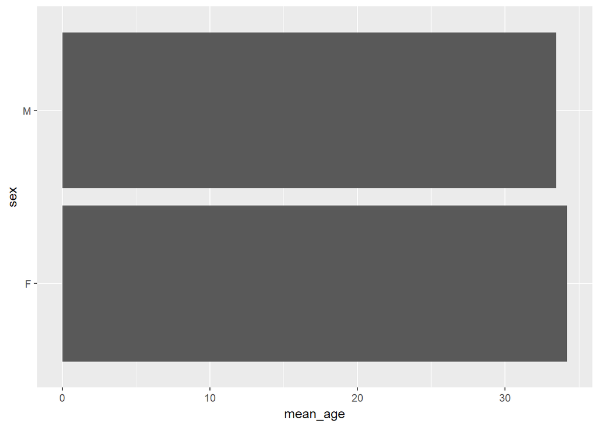

```r
average %>%
  ggplot(aes(x=sex, y=mean_age))+
    coord_flip()+
    geom_bar(stat="identity")
```

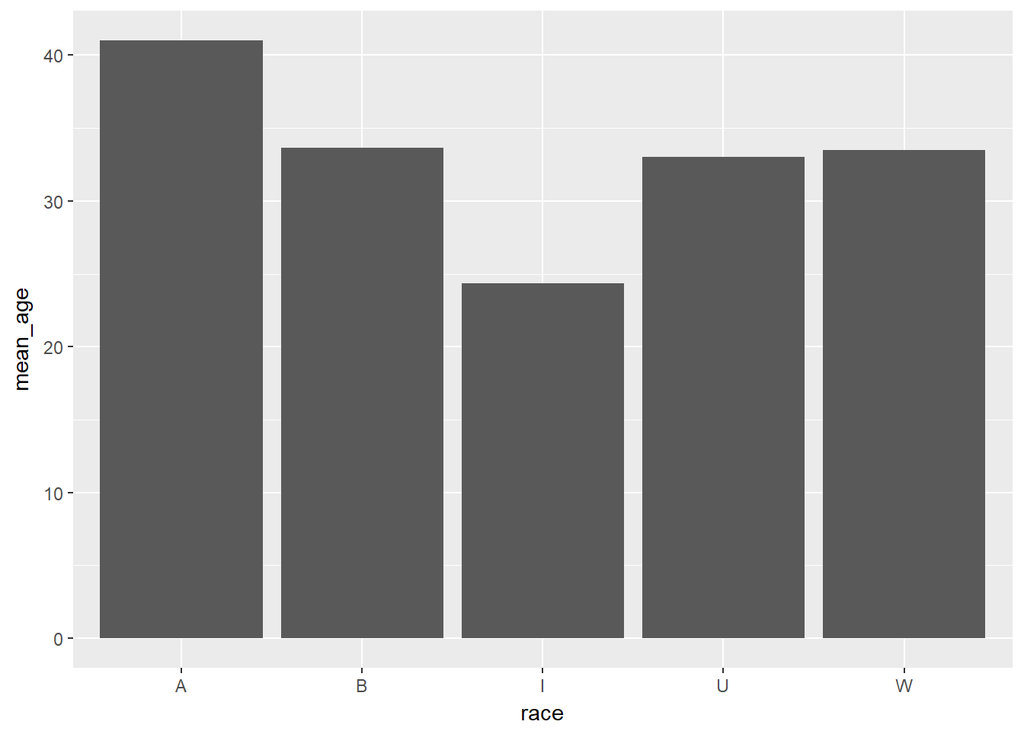

```r
average2 <- dat %>%
  select(race, age)%>%
  group_by(race)%>%
  summarize(mean_age=mean(age))%>%
  arrange(mean_age)
average2 %>%
  ggplot(aes(x=race, y=mean_age))+
    geom_bar(stat="identity")
```

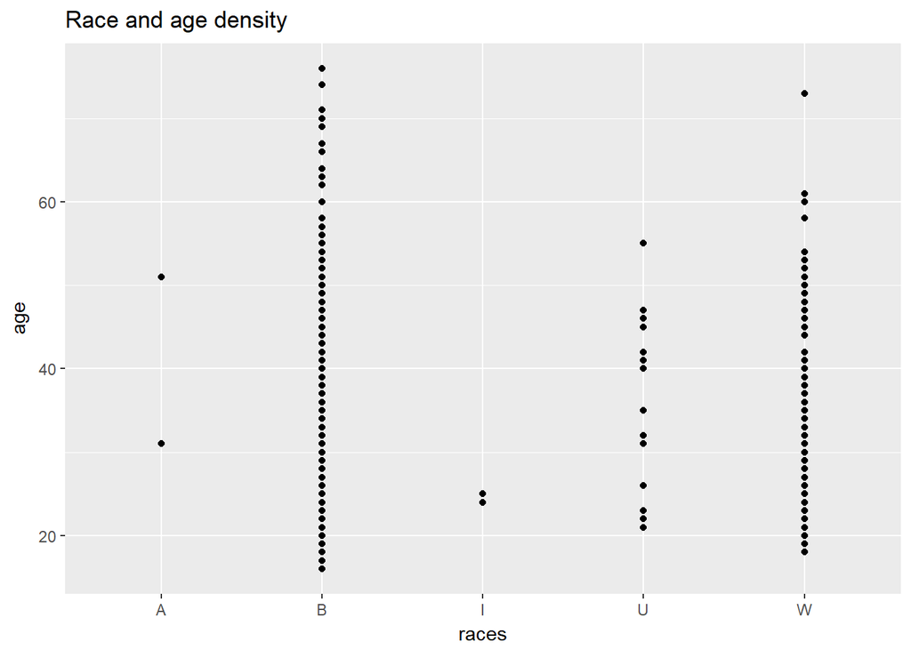

```r
wr <- dat %>%
  select(race, age)%>%
  group_by(race)%>%
  ggplot(aes(x = race, y = age)) +
    geom_point() +
    xlab("races") +
    ylab("age") +
    ggtitle("Race and age density")
wr
```

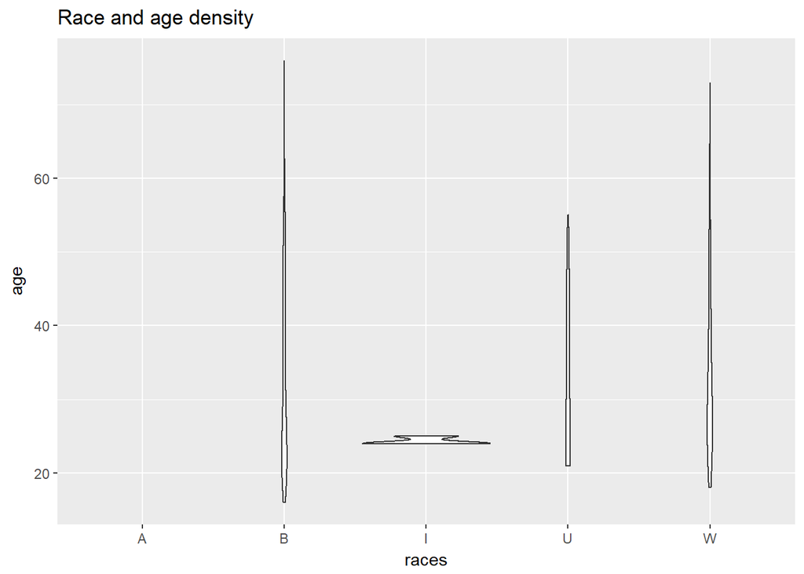

```r
wr <- dat %>%
  select(race, age)%>%
  group_by(race)%>%
  ggplot(aes(x = race, y = age)) +
    geom_violin() +
    xlab("races") +
    ylab("age") +
    ggtitle("Race and age density")
wr
```

if we wanted to analyze unmbers based on time, first we need to change arrestDate to a date format that machine recognizes using as.Date, then we can do a plot with number of arrests within two yeras.

but in this graph we can make a comparison. first we mutated two colomns, month and year, then found how many arresst each month in each year have by summarize in n().

```r
dat$arrestDate<- as.Date(dat$arrestDate, "%m/%d/%Y")
mons <- dat%>%
  mutate(month = format(arrestDate, "%m"))%>%
  mutate(year = format(arrestDate, "%Y"))%>%
  group_by(year,month)%>%
  summarise(numarrest=n())
```

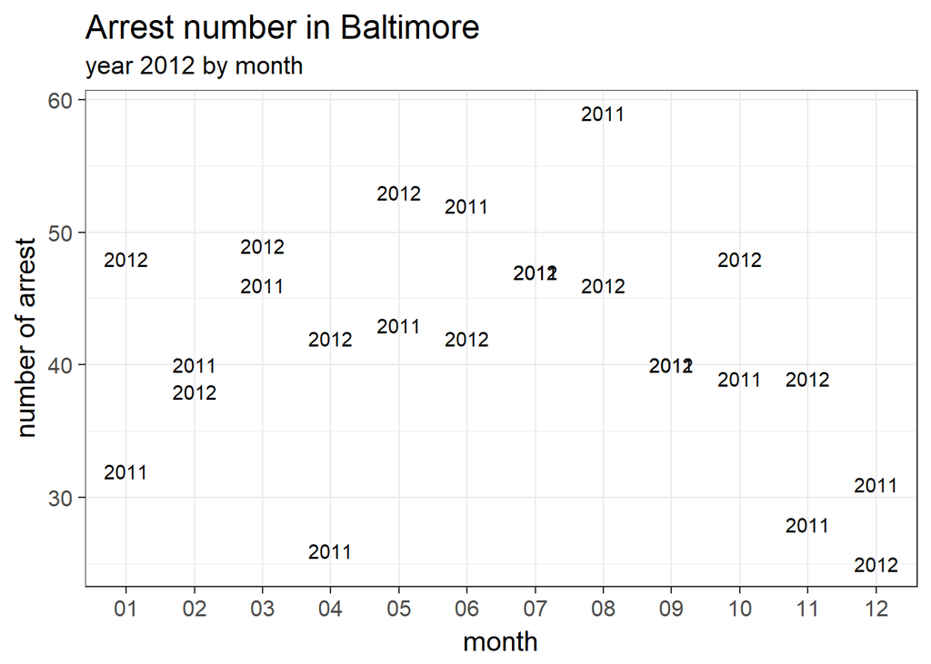

```r
mons$year <- as.integer(mons$year)
mons %>%
  group_by(year, month)%>%
  ggplot(aes(x = month, y = numarrest, label=year)) +
      geom_text() +
      labs(title = "Arrest number in Baltimore",
           subtitle = "year 2012 by month",
           y = "number of arrest",
           x = "month") + theme_bw(base_size = 15)
```

although we can not see things change chronologically, we may be able to find relations on age of suspects. first we group all arrests by age and count them up. then we use a point plot and make a regression line with geom_smooth(method=lm). and we have a clear negative relationship between age and number of arrests. excepts age lover than 18, number of arrests are reversed with age of suspects. which means there were more young people arrested than old people in Baltimore in year of 2011 and 2012.

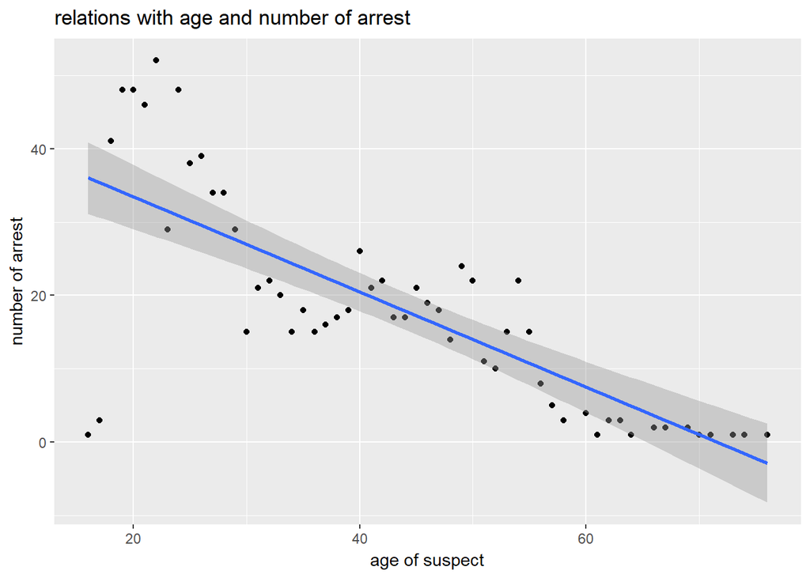

```r
age <- dat%>%
  group_by(age)%>%
  summarise(numarrest=n())
age %>%
  ggplot(mapping=aes(y=numarrest,x=age))+
  geom_point()+
  geom_smooth(method=lm)+
  xlab("age of suspect")+
  ylab("number of arrest")+
  ggtitle("relations with age and number of arrest")
```

```r
model <-
    lm(age~numarrest, data=age)
  tidied_model <-
    model %>%
    tidy() %>%
    select(term, estimate, statistic, p.value)
  tidied_model
```

```
##          term estimate statistic      p.value
## 1 (Intercept) 60.18697 25.343942 1.173495e-31
## 2   numarrest -0.90347 -8.723186 6.831698e-12
```

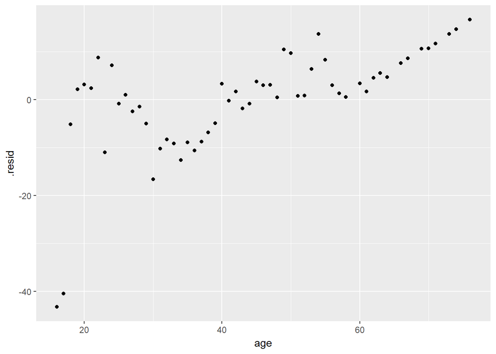

```r
 residuals <-
    model %>%
    augment()
  residual_plot <-
    residuals %>%
    ggplot(aes(x=age, y=.resid)) +
    geom_point()
  residual_plot
```

same as date and year, we can easily found what time at a day there are most arrests and least arrests. first we extract hour out of arrestTime by mutate and group_by its hour number extraction. then we can plot the relations in graph.

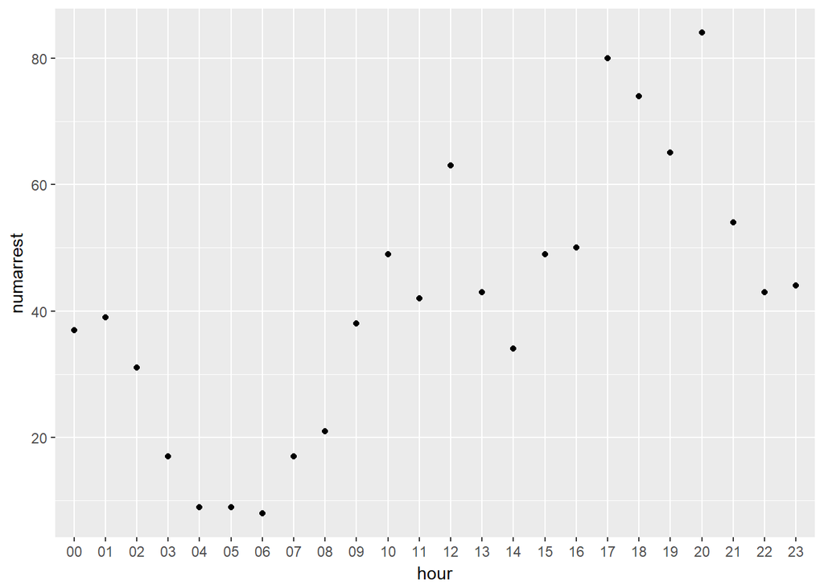

```r
mons <- dat%>%
  mutate(hour = format(arrestTime, "%h"))%>%
  group_by(hour = str_extract(hour, "[0-9][0-9]+"))%>%
  summarise(numarrest=n())
mons%>%
  ggplot(aes(x=hour,y=numarrest))+
           geom_point()
```

if we wanted to know which distrct has more arrests, we can simply do what we did before and plot a bar graph on count. from this plot, we can say that the northern district had a lower number of arrests, maybe it could be safer than others

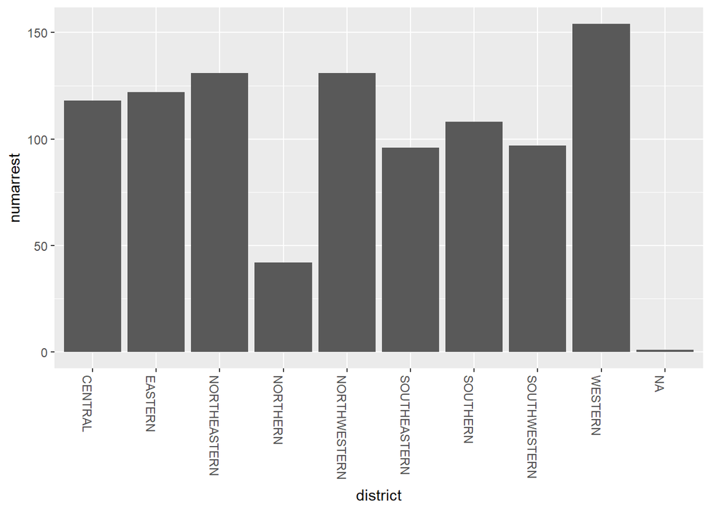

```r
dis <- dat%>%
  group_by(district)%>%
  summarise(numarrest=n())
dis %>%
  ggplot(aes(x=district, y=numarrest))+
  geom_bar(stat="identity")+
  theme(axis.text.x=element_text(angle=-90, hjust=0))
```

also there is a plug in that allows us to draw it on maps. in previous sections we have already seperated latitude and longitude for mapping. this is a map that shows arrests in baltimore based on the database provided. it has male and female markers for different genders and age show upon click. defult to be clusted together. just zoom in we can find more detailed locations of each specific arrests took place and gender of suspects.

```r
mfIcons <- icons(
  iconUrl = ifelse(dat$sex=="M",
    "http://icons.iconarchive.com/icons/custom-icon-design/flatastic-7/512/Male-icon.png",
    "http://icons.iconarchive.com/icons/custom-icon-design/flatastic-7/512/Female-icon.png"
  ),
  iconWidth = 15, iconHeight = 15,
  iconAnchorX = 22, iconAnchorY = 94
)
balto_map <- leaflet(dat) %>%
  addTiles() %>%
  setView(lat=39.29, lng=-76.61, zoom=11)%>%
  addMarkers(~lng, ~lat, icon = mfIcons,popup = ~as.character(age),
  clusterOptions = markerClusterOptions())
balto_map
```

[interactive chart not shown]

this database contains more charactersthan numbers, so it woul dbe better if we switch to another database. Here we will be getting data from this database and perform a cross validation. it is a process that generates error in our analysis and tell us how well our model fits.

first we need to clean the table. let it only contains information suits our needs. this is a world wide map so what we need to do is drop invalide NAs and filter to get US regiones. then let it contains only time location and affordability. also we need to set a time boundary for this table so that it is easier to manage. in order to make use of the affordability trend, we have a ifels generating whether it is going up or down. After all these preperations, we can start the cross validation.

```r
csv_file <- "http://www.hcbravo.org/IntroDataSci/misc/Affordability_Wide_2017Q4_Public.csv"
tidy_afford <- read_csv(csv_file) %>%
  filter(Index == "Mortgage Affordability") %>%
  drop_na() %>%
  filter(RegionID != 0, RegionName != "United States") %>%
  dplyr::select(RegionID, RegionName, matches("^[1|2]")) %>%
  gather(time, affordability, matches("^[1|2]")) %>%
  type_convert(col_types=cols(time=col_date(format="%Y-%m")))
tidy_afford
```

```
## # A tibble: 12,480 x 4
##    RegionID RegionName                         time       affordability
##       <int> <chr>                              <date>             <dbl>
##  1   394913 New York, NY                       1979-03-01         0.262
##  2   753899 Los Angeles-Long Beach-Anaheim, CA 1979-03-01         0.358
##  3   394463 Chicago, IL                        1979-03-01         0.262
##  4   394514 Dallas-Fort Worth, TX              1979-03-01         0.301
##  5   394974 Philadelphia, PA                   1979-03-01         0.204
##  6   394692 Houston, TX                        1979-03-01         0.243
##  7   395209 Washington, DC                     1979-03-01         0.254
##  8   394856 Miami-Fort Lauderdale, FL          1979-03-01         0.268
##  9   394347 Atlanta, GA                        1979-03-01         0.248
## 10   394404 Boston, MA                         1979-03-01         0.222
## # ... with 12,470 more rows
```

```r
outcome_df <- tidy_afford %>%
  mutate(yq = quarter(time, with_year=TRUE)) %>%
  filter(yq %in% c("2016.4", "2017.4")) %>%
  select(RegionID, RegionName, yq, affordability) %>%
  spread(yq, affordability) %>%
  mutate(diff = `2017.4` - `2016.4`) %>%
  mutate(Direction = ifelse(diff>0, "up", "down")) %>%
  select(RegionID, RegionName, Direction)
outcome_df
```

```
## # A tibble: 80 x 3
##    RegionID RegionName      Direction
##       <int> <chr>           <chr>
##  1   394304 Akron, OH       down
##  2   394312 Albuquerque, NM down
##  3   394318 Allentown, PA   down
##  4   394347 Atlanta, GA     up
##  5   394355 Austin, TX      up
##  6   394357 Bakersfield, CA down
##  7   394358 Baltimore, MD   down
##  8   394367 Baton Rouge, LA up
##  9   394378 Bellingham, WA  up
## 10   394388 Birmingham, AL  down
## # ... with 70 more rows
```

```r
predictor_df <- tidy_afford %>%
  filter(year(time) <= 2016)
```

first we filter years of interest and get statistics based on regionID, there are mean, sd and z value of these.

```r
standardized_df <- predictor_df %>%
  filter(year(time) %in% 2006:2016) %>%
  group_by(RegionID) %>%
  mutate(mean_aff = mean(affordability)) %>%
  mutate(sd_aff = sd(affordability)) %>%
  mutate(z_aff = (affordability - mean_aff) / sd_aff) %>%
  ungroup()
standardized_df
```

```
## # A tibble: 3,520 x 7
##    RegionID RegionName      time       affordability mean_aff sd_aff z_aff
##       <int> <chr>           <date>             <dbl>    <dbl>  <dbl> <dbl>
##  1   394913 New York, NY    2006-03-01         0.422    0.292 0.0650  2.00
##  2   753899 Los Angeles-Lo~ 2006-03-01         0.658    0.422 0.107   2.21
##  3   394463 Chicago, IL     2006-03-01         0.257    0.171 0.0473  1.83
##  4   394514 Dallas-Fort Wo~ 2006-03-01         0.163    0.131 0.0182  1.79
##  5   394974 Philadelphia, ~ 2006-03-01         0.245    0.176 0.0381  1.80
##  6   394692 Houston, TX     2006-03-01         0.143    0.122 0.0141  1.48
##  7   395209 Washington, DC  2006-03-01         0.317    0.202 0.0496  2.32
##  8   394856 Miami-Fort Lau~ 2006-03-01         0.395    0.217 0.0818  2.18
##  9   394347 Atlanta, GA     2006-03-01         0.179    0.130 0.0272  1.80
## 10   394404 Boston, MA      2006-03-01         0.354    0.242 0.0463  2.42
## # ... with 3,510 more rows
```

then we can work on quarterly difference. we have created two matrix.

```r
wide_df <- standardized_df %>%
  select(RegionID, time, z_aff) %>%
  tidyr::spread(time, z_aff)
wide_df
```

```
## # A tibble: 80 x 45
##    RegionID `2006-03-01` `2006-06-01` `2006-09-01` `2006-12-01`
##       <int>        <dbl>        <dbl>        <dbl>        <dbl>
##  1   394304        1.85          2.09         1.86         1.62
##  2   394312        1.04          1.44         1.45         1.45
##  3   394318        1.74          2.05         1.88         1.64
##  4   394347        1.80          2.04         1.84         1.61
##  5   394355        0.925         1.52         1.29         1.04
##  6   394357        2.27          2.43         2.17         1.94
##  7   394358        1.85          2.10         1.91         1.67
##  8   394367        1.75          2.05         1.78         1.16
##  9   394378        1.72          1.96         1.68         1.54
## 10   394388        1.72          1.94         1.56         1.34
## # ... with 70 more rows, and 40 more variables: `2007-03-01` <dbl>,
## #   `2007-06-01` <dbl>, `2007-09-01` <dbl>, `2007-12-01` <dbl>,
## #   `2008-03-01` <dbl>, `2008-06-01` <dbl>, `2008-09-01` <dbl>,
## #   `2008-12-01` <dbl>, `2009-03-01` <dbl>, `2009-06-01` <dbl>,
## #   `2009-09-01` <dbl>, `2009-12-01` <dbl>, `2010-03-01` <dbl>,
## #   `2010-06-01` <dbl>, `2010-09-01` <dbl>, `2010-12-01` <dbl>,
## #   `2011-03-01` <dbl>, `2011-06-01` <dbl>, `2011-09-01` <dbl>,
## #   `2011-12-01` <dbl>, `2012-03-01` <dbl>, `2012-06-01` <dbl>,
## #   `2012-09-01` <dbl>, `2012-12-01` <dbl>, `2013-03-01` <dbl>,
## #   `2013-06-01` <dbl>, `2013-09-01` <dbl>, `2013-12-01` <dbl>,
## #   `2014-03-01` <dbl>, `2014-06-01` <dbl>, `2014-09-01` <dbl>,
## #   `2014-12-01` <dbl>, `2015-03-01` <dbl>, `2015-06-01` <dbl>,
## #   `2015-09-01` <dbl>, `2015-12-01` <dbl>, `2016-03-01` <dbl>,
## #   `2016-06-01` <dbl>, `2016-09-01` <dbl>, `2016-12-01` <dbl>
```

```r
matrix_1 <- wide_df %>%
  select(-RegionID) %>%
  as.matrix() %>%
  .[,-1]

matrix_2 <- wide_df %>%
  select(-RegionID) %>%
  as.matrix() %>%
  .[,-ncol(.)]

diff_df <- (matrix_1 - matrix_2) %>%
  magrittr::set_colnames(NULL) %>%
  as_data_frame() %>%
  mutate(RegionID = wide_df$RegionID)

final_df <- diff_df %>%
  inner_join(outcome_df %>% select(RegionID, Direction), by="RegionID") %>%
  mutate(Direction=factor(Direction, levels=c("down", "up")))
final_df
```

```
## # A tibble: 80 x 45
##       V1      V2       V3      V4     V5     V6     V7      V8      V9
##    <dbl>   <dbl>    <dbl>   <dbl>  <dbl>  <dbl>  <dbl>   <dbl>   <dbl>
##  1 0.239 -0.226  -0.242   -0.0437 0.255  -0.258 -0.207 -0.210   0.0987
##  2 0.401  0.0147 -0.00176  0.132  0.305  -0.237 -0.190 -0.115   0.123
##  3 0.307 -0.171  -0.234   -0.0425 0.240  -0.262 -0.242 -0.172   0.0436
##  4 0.243 -0.203  -0.230   -0.0969 0.280  -0.230 -0.235 -0.132   0.0614
##  5 0.591 -0.223  -0.255    0.109  0.643  -0.266 -0.103  0.0372  0.333
##  6 0.159 -0.257  -0.235   -0.0998 0.0689 -0.369 -0.380 -0.299  -0.148
##  7 0.254 -0.194  -0.241   -0.0644 0.219  -0.241 -0.229 -0.184   0.0425
##  8 0.302 -0.273  -0.621    0.190  0.454  -0.544 -0.324 -0.0909  0.548
##  9 0.248 -0.282  -0.143    0.0298 0.298  -0.201 -0.284 -0.0572  0.0842
## 10 0.216 -0.375  -0.223   -0.0150 0.295  -0.176 -0.261 -0.172   0.215
## # ... with 70 more rows, and 36 more variables: V10 <dbl>, V11 <dbl>,
## #   V12 <dbl>, V13 <dbl>, V14 <dbl>, V15 <dbl>, V16 <dbl>, V17 <dbl>,
## #   V18 <dbl>, V19 <dbl>, V20 <dbl>, V21 <dbl>, V22 <dbl>, V23 <dbl>,
## #   V24 <dbl>, V25 <dbl>, V26 <dbl>, V27 <dbl>, V28 <dbl>, V29 <dbl>,
## #   V30 <dbl>, V31 <dbl>, V32 <dbl>, V33 <dbl>, V34 <dbl>, V35 <dbl>,
## #   V36 <dbl>, V37 <dbl>, V38 <dbl>, V39 <dbl>, V40 <dbl>, V41 <dbl>,
## #   V42 <dbl>, V43 <dbl>, RegionID <int>, Direction <fct>
```

cross validation the whole part, first we need to fit and gather results, then split to train, then gather a final result.

```r
result <- createFolds(final_df$Direction, k=10)%>%
  purrr::imap(function(test_indices,fold_number){
    db_train<- final_df%>%
      select(-RegionID)%>%
      slice(-test_indices)
    ts1<-randomForest(Direction~.,data=db_train, ntree=500)
    db_test<-final_df%>%
      select(-RegionID)%>%
      slice(test_indices)
    db_test%>%
      select(labelgot=Direction)%>%
      mutate(fold=fold_number)%>%
      mutate(prob_pos=predict(ts1, newdata=db_test, type="prob")[,"up"])%>%
      mutate(prelab=ifelse(prob_pos>0.5, "up", "down"))
  })%>%
  purrr::reduce(bind_rows)
result
```

```
## # A tibble: 80 x 4
##    labelgot fold   prob_pos prelab
##    <fct>    <chr>     <dbl> <chr>
##  1 down     Fold01    0.754 up
##  2 up       Fold01    0.766 up
##  3 up       Fold01    0.612 up
##  4 up       Fold01    0.584 up
##  5 up       Fold01    0.418 down
##  6 up       Fold01    0.938 up
##  7 up       Fold01    0.760 up
##  8 down     Fold01    0.404 down
##  9 down     Fold01    0.730 up
## 10 down     Fold02    0.476 down
## # ... with 70 more rows
```

then print out the result and do a curve plot on average true positive rate and average false positive rate.

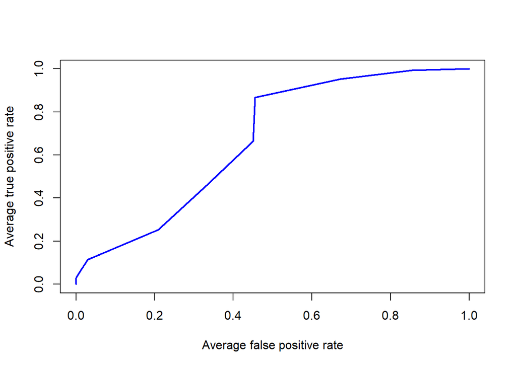

```r
labels <- split(result$labelgot, result$fold)

mean_auc<-split(result$prob_pos, result$fold)%>%
  prediction(labels)%>%
  performance(measure="auc")%>%
  slot("y.values")%>%unlist()%>%mean()

predictions_all<-
  split(result$prob_pos, result$fold)%>%
  prediction(labels)%>%
  performance(measure="tpr", x.measure="fpr")%>%
  plot(avg="threshold", col="blue", lwd=2)
```

After this tutorial, you may be able to analyze and plot out of a csv databse. As it is mentioned, R is a simple easy to use language with powerful commands. For every readers, hope you can get some help from this tutorial and be able to use it when you need it.